# Initial Value Problem

```python
%matplotlib inline
import numpy as np
import matplotlib.pyplot as plt
```

## Question 1

Implement the Euler algorithm and use it to solve the following problems

- a) $y' = 0.5 y$ with $y(0) = 1$ in the range $[0, 5]$ in steps of $0.1$
- b) $y'' =-4.0 y$ with $y(0) = 1$ and $y'(0) = 0$ in the range $[0, 5]$ in steps of $0.2$

For each case, do:

- what are the analytical solution of these problems ?
- Plot both the analytical solution and the results of the integration
- What is the order of the accumulated error from a theoretical point of view.
- What is precisely the error for $y(5)$ ?

```python
import numpy as np
def integrate_Euler(F,x,y,xStop,h):
    X = []
    Y = []
    X.append(x)
    Y.append(y)
    while abs(xStop-x)>10**-12:
        h = min(h,xStop - x)
        y = y + h*F(x,y)
        x = x + h
        X.append(x)
        Y.append(y)
    return np.array(X),np.array(Y)
```

```
51
51
51
[0.  0.1 0.2 0.3 0.4 0.5 0.6 0.7 0.8 0.9 1.  1.1 1.2 1.3 1.4 1.5 1.6 1.7
 1.8 1.9 2.  2.1 2.2 2.3 2.4 2.5 2.6 2.7 2.8 2.9 3.  3.1 3.2 3.3 3.4 3.5
 3.6 3.7 3.8 3.9 4.  4.1 4.2 4.3 4.4 4.5 4.6 4.7 4.8 4.9 5. ]
ERROR= 0.7150941749497974
```

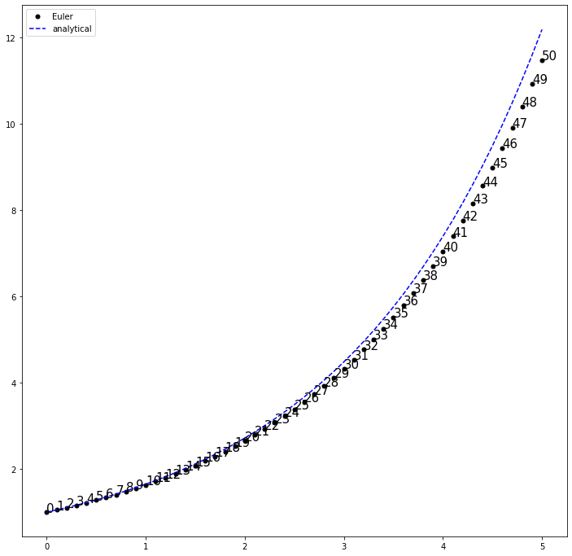

```python
#a)y'  = 0.5

def F(x,y):
    return 0.5*y

x_start = 0.
x_stop  = 5.
y_start = 1.0
h = 0.1
results = integrate_Euler(F, x_start, y_start, x_stop, h)
euler_x = results[0]
euler_y = results[1][:]

fig, ax = plt.subplots(figsize=(12, 12))
plt.plot(euler_x, euler_y, "o", color="black", markersize=5, label="Euler")
for i in range(len(euler_x)):
    ax.annotate("%d" % i, xy=(euler_x[i], euler_y[i]), xytext=(euler_x[i], euler_y[i]*1.001), fontsize=15 )


def analytical(x):
    return y_start*np.exp(0.5*x)

analytical_x = np.arange(x_start,x_stop+h, h)
analytical_y = analytical(analytical_x)

print(len(analytical_y))
print(len(euler_y))
print(len(euler_x))
print(euler_x)

plt.plot(analytical_x, analytical_y, "--", color="blue", label="analytical")

print("ERROR=", np.abs(analytical_y[-1]-euler_y[-1]) )

ax.legend()
```

```
X's: [0.  0.2 0.4 0.6 0.8 1.  1.2 1.4 1.6 1.8 2.  2.2 2.4 2.6 2.8 3.  3.2 3.4
 3.6 3.8 4.  4.2 4.4 4.6 4.8 5. ]
Y's: [ 1.          1.          0.84        0.52        0.0656     -0.472
 -1.020096   -1.492672   -1.80203264 -1.87256576 -1.65477366 -1.13737103
 -0.35520462  0.60894115  1.62991966  2.5534676   3.21622838  3.47043435
  3.21004378  2.39438371  1.06511664 -0.64725183 -2.53003896 -4.30926579
 -5.68368639 -6.36862447]
ERROR= 5.529552937818053
```

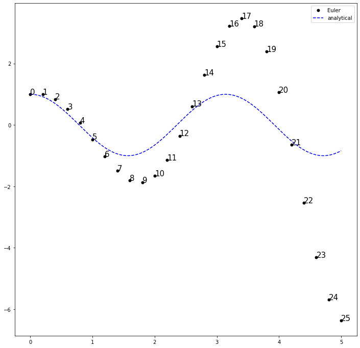

```python
#a)y'' = 0.5 y

def F(x,y):
    F = np.zeros(2)
    F[0] = y[1]
    F[1] = -4*y[0]
    return F

x_start = 0.
x_stop  = 5.
y_start = np.array([1.0, 0.0])
h = 0.2
results = integrate_Euler(F, x_start, y_start, x_stop, h)
euler_x = results[0]
euler_y = results[1][:,0]
print("X's:", euler_x)
print("Y's:", euler_y)

fig, ax = plt.subplots(figsize=(12, 12))


plt.plot(euler_x, euler_y, "o", color="black", markersize=5, label="Euler")
for i in range(len(euler_x)):
    ax.annotate("%d" % i, xy=(euler_x[i], euler_y[i]), xytext=(euler_x[i], euler_y[i]*1.001), fontsize=15 )


def analytical(x):
    return y_start[0]*np.cos(np.sqrt(4)*x)

analytical_x = np.arange(x_start,x_stop+h/10.0, h/10.0)
analytical_y = analytical(analytical_x)

plt.plot(analytical_x, analytical_y, "--", color="blue", label="analytical")

print("ERROR=", np.abs(analytical_y[-1]-euler_y[-1]) )
ax.legend()
```

## Question 2

Implement the RK4 algorithm and answer the same question than in Question1

```python
def integrate_RK4(F,x,y,xStop,h):

    def run_kut4(F,x,y,h):
        K0 = h*F(x,y)
        K1 = h*F(x + h/2.0, y + K0/2.0)
        K2 = h*F(x + h/2.0, y + K1/2.0)
        K3 = h*F(x + h, y + K2)
        return (K0 + 2.0*K1 + 2.0*K2 + K3)/6.0

    X = []
    Y = []
    X.append(x)
    Y.append(y)
    while x < xStop:
        h = min(h,xStop - x)
        y = y + run_kut4(F,x,y,h)
        x = x + h
        X.append(x)
        Y.append(y)
    return np.array(X),np.array(Y)
```

```
ERROR= 1.5215637478860344e-06
```

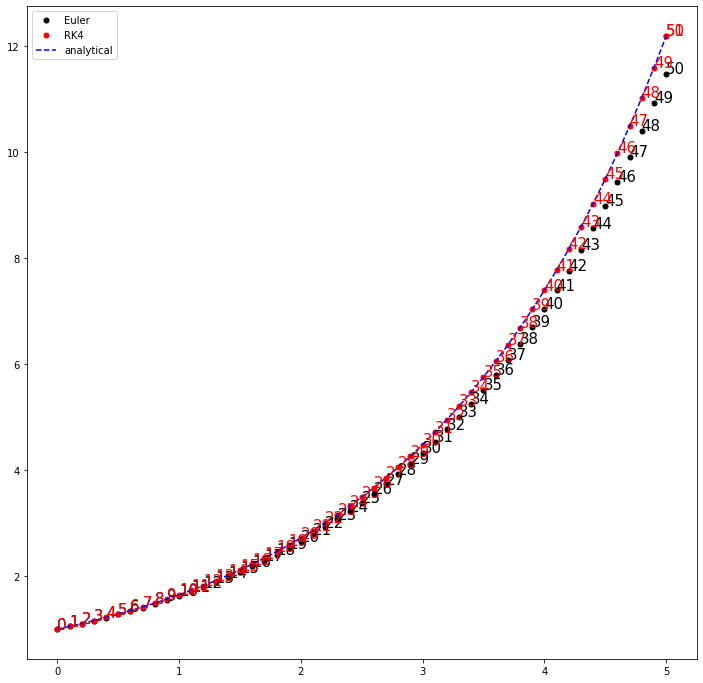

```python
def F(x,y):
    return 0.5*y

x_start = 0.
x_stop  = 5.
y_start = 1.0
h = 0.1
results = integrate_Euler(F, x_start, y_start, x_stop, h)
euler_x = results[0]
euler_y = results[1][:]

results = integrate_RK4(F, x_start, y_start, x_stop, h)
rk4_x = results[0]
rk4_y = results[1][:]


fig, ax = plt.subplots(figsize=(12, 12))
plt.plot(euler_x, euler_y, "o", color="black", markersize=5, label="Euler")
for i in range(len(euler_x)):
    ax.annotate("%d" % i, xy=(euler_x[i], euler_y[i]), xytext=(euler_x[i], euler_y[i]*1.001), fontsize=15 )

plt.plot(rk4_x, rk4_y, "o", color="red", markersize=5, label="RK4")
for i in range(len(rk4_x)):
    ax.annotate("%d" % i, xy=(rk4_x[i], rk4_y[i]), xytext=(rk4_x[i], rk4_y[i]*1.001), fontsize=15, color="red" )


def analytical(x):
    return y_start*np.exp(0.5*x)

analytical_x = np.arange(x_start,x_stop+h/10.0, h/10.0)
analytical_y = analytical(analytical_x)

plt.plot(analytical_x, analytical_y, "--", color="blue", label="analytical")

print("ERROR=", np.abs(analytical_y[-1]-rk4_y[-1]) )

ax.legend()
```

```
ERROR= 0.000507960692175291
```

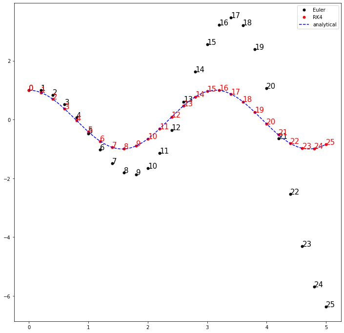

```python
def F(x,y):
    F = np.zeros(2)
    F[0] = y[1]
    F[1] = -4*y[0]
    return F

x_start = 0.
x_stop  = 5.
y_start = np.array([1.0, 0.0])
h = 0.2
results = integrate_Euler(F, x_start, y_start, x_stop, h)
euler_x = results[0]
euler_y = results[1][:,0]

results = integrate_RK4(F, x_start, y_start, x_stop, h)
rk4_x = results[0]
rk4_y = results[1][:,0]


fig, ax = plt.subplots(figsize=(12, 12))


plt.plot(euler_x, euler_y, "o", color="black", markersize=5, label="Euler")
for i in range(len(euler_x)):
    ax.annotate("%d" % i, xy=(euler_x[i], euler_y[i]), xytext=(euler_x[i], euler_y[i]*1.001), fontsize=15 )

plt.plot(rk4_x, rk4_y, "o", color="red", markersize=5, label="RK4")
for i in range(len(rk4_x)):
    ax.annotate("%d" % i, xy=(rk4_x[i], rk4_y[i]), xytext=(rk4_x[i], rk4_y[i]*1.001), fontsize=15, color="red" )


def analytical(x):
    return y_start[0]*np.cos(np.sqrt(4)*x)

analytical_x = np.arange(x_start,x_stop+h/10.0, h/10.0)
analytical_y = analytical(analytical_x)

plt.plot(analytical_x, analytical_y, "--", color="blue", label="analytical")

print("ERROR=", np.abs(analytical_y[-1]-rk4_y[-1]) )
ax.legend()
```

## Question 3 - spring–mass system

[figure not shown]

The movement of a spring-mass system is defined by the following differential equation:

$\Large m{\frac {d^{2}x}{dt^{2}}}+c{\frac {dx}{dt}}+kx=0 $

Where:

- $x(t)$ is the body position at time $t$
- $t$ is the time variable
- $m$ is the mass of the body attached to the spring
- $c$ is the damping coefficient
- $k$ is the spring constant,

Can you solve the system for

- $c = 0.95$
- $k = 5 $
- $m = 1.5$
- $x(0) = 10$
- $x'(0) = 0$

We are particularly interested in the position of the body at $t=15$ and to know (approximately) for how long the body will have oscillations with an amplitude larger than 0.1

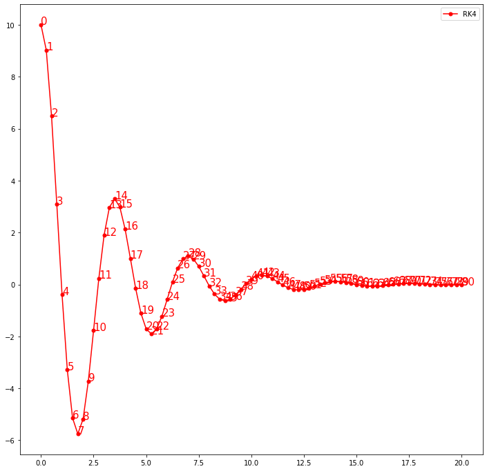

[figure not shown]

```python
def F(x,y):
    c = 0.95
    k = 5
    m = 1.5
    F = np.zeros(2)
    F[0] = y[1]
    F[1] = (-k*y[0]-c*y[1])/m
    return F

x_start = 0.
x_stop  = 20.
y_start = np.array([10.0, 0.0])
h = 0.25

results = integrate_RK4(F, x_start, y_start, x_stop, h)
rk4_x = results[0]
rk4_y = results[1][:,0]


fig, ax = plt.subplots(figsize=(12, 12))
plt.plot(rk4_x, rk4_y, "-o", color="red", markersize=5, label="RK4")
for i in range(len(rk4_x)):
    ax.annotate("%d" % i, xy=(rk4_x[i], rk4_y[i]), xytext=(rk4_x[i], rk4_y[i]*1.001), fontsize=15, color="red" )
ax.legend()
fig.show()


fig, ax = plt.subplots(figsize=(12, 12))
plt.plot(rk4_x, rk4_y, "-o", color="red", markersize=5, label="RK4")
for i in range(len(rk4_x)):
    ax.annotate("%d" % i, xy=(rk4_x[i], rk4_y[i]), xytext=(rk4_x[i], rk4_y[i]*1.001), fontsize=15, color="red" )
ax.legend()
plt.hlines(0.1, x_start, x_stop)
plt.hlines(-0.1, x_start, x_stop)
ax.set_ylim([-0.3,0.3])
ax.grid()
fig.show()
```

## Question 4

Solve the equation: $\Large y''=2y'y$

Use the following initial conditions and range:

- $y(0) = 1$; $y'(0)=-1$; $x$-range $=[0; 10]$
- $y(0) = 0$; $y'(0)=1$; $x$-range $=[0; 1.5]$

Plot the solution

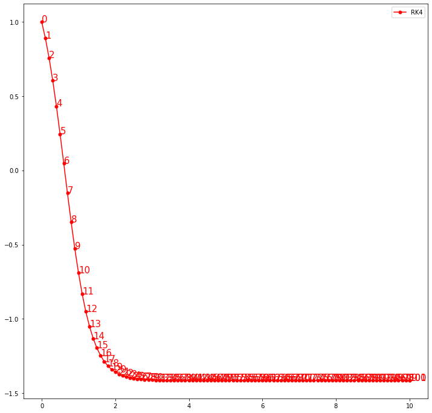

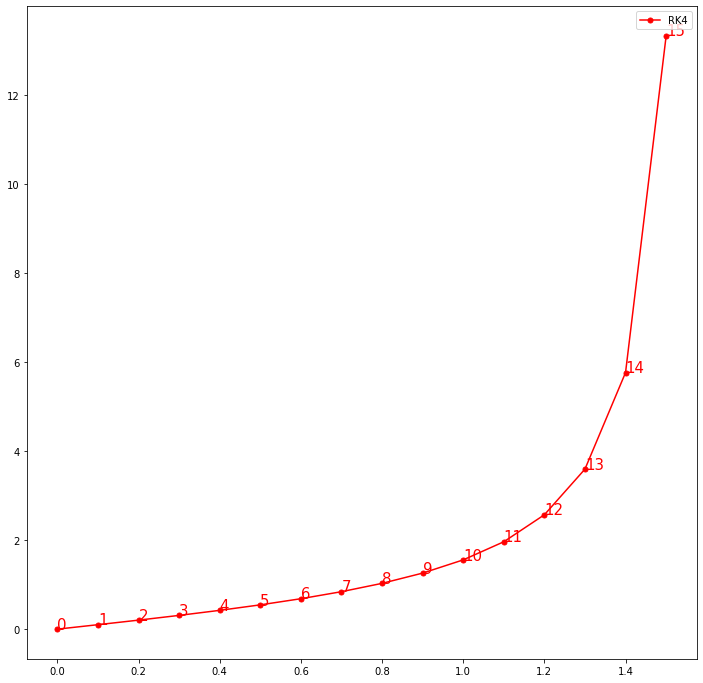

```python
def F(x,y):
    F = np.zeros(2)
    F[0] = y[1]
    F[1] = 2*y[0]*y[1]
    return F

x_start = 0.
x_stop  = 10.
y_start = np.array([1.0,-1.0])
h = 0.1

results = integrate_RK4(F, x_start, y_start, x_stop, h)
rk4_x = results[0]
rk4_y = results[1][:,0]


fig, ax = plt.subplots(figsize=(12, 12))
plt.plot(rk4_x, rk4_y, "-o", color="red", markersize=5, label="RK4")
for i in range(len(rk4_x)):
    ax.annotate("%d" % i, xy=(rk4_x[i], rk4_y[i]), xytext=(rk4_x[i], rk4_y[i]*1.001), fontsize=15, color="red" )
ax.legend()
fig.show()


x_start = 0.
x_stop  = 1.5
y_start = np.array([0.0,1.0])
h = 0.1

results = integrate_RK4(F, x_start, y_start, x_stop, h)
rk4_x = results[0]
rk4_y = results[1][:,0]

fig, ax = plt.subplots(figsize=(12, 12))
plt.plot(rk4_x, rk4_y, "-o", color="red", markersize=5, label="RK4")
for i in range(len(rk4_x)):
    ax.annotate("%d" % i, xy=(rk4_x[i], rk4_y[i]), xytext=(rk4_x[i], rk4_y[i]*1.001), fontsize=15, color="red" )
ax.legend()
fig.show()
```

## Question 5 - Balistic

Solve the balistic problem using ODE. A plane with an horizontal velocity (along axis $x$) of $x'=15 \mathrm{m/s}$ drops a bomb at an altitude of $2500 \mathrm m$. The bomb is attracted by the ground according to Newton's gravity. It's accelartion along axis $y$ is therefore $y''=-9.81$.

when and where will the bomb touch the ground ? (plane $x$ position at dropping was 0)

hint: modify the RK4 alorithm to stop when $y$ position is bellow 0

```
touch the ground after between 22.574999999999793 and 22.579999999999792 seconds
impact position is 338.6624999999715 -0.29192881236544665
```

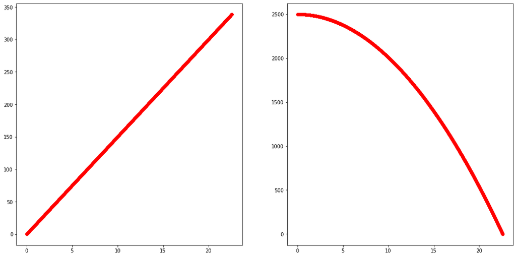

```python
def integrate_RK4_with_stopper(F,x,y,xStop,h, should_stop=None):

    def run_kut4(F,x,y,h):
        K0 = h*F(x,y)
        K1 = h*F(x + h/2.0, y + K0/2.0)
        K2 = h*F(x + h/2.0, y + K1/2.0)
        K3 = h*F(x + h, y + K2)
        return (K0 + 2.0*K1 + 2.0*K2 + K3)/6.0

    X = []
    Y = []
    X.append(x)
    Y.append(y)
    while x < xStop:
        h = min(h,xStop - x)
        y = y + run_kut4(F,x,y,h)
        x = x + h
        X.append(x)
        Y.append(y)
        if(should_stop is not None and should_stop(x,y)): break
    return np.array(X),np.array(Y)


def should_stop(t, y):
    y = y[1]
    if(y<0.0): return True
    return False

def F(t,xy):
    F = np.zeros(3)
    F[0] = 15
    F[1] = xy[2]
    F[2] = -9.81
    return F

t_start = 0.
t_stop  = 25.
xy_start = np.array([0,2500,0])
h = 0.005

results = integrate_RK4_with_stopper(F, t_start, xy_start, t_stop, h, should_stop=should_stop)
rk4_t = results[0]
rk4_x = results[1][:,0]
rk4_y = results[1][:,1]

print("touch the ground after between",rk4_t[-2],"and",rk4_t[-1], "seconds")
print("impact position is", rk4_x[-2:].mean(), rk4_y[-2:].mean())

fig, axes = plt.subplots(1,2, figsize=(18, 9))

axes[0].plot(rk4_t, rk4_x, "-o", color="red", markersize=5, label="RK4")
axes[1].plot(rk4_t, rk4_y, "-o", color="red", markersize=5, label="RK4")

fig.show()
```

## Question 6 2-body problem

- have fun with the 2 body problem as we saw it in the class room

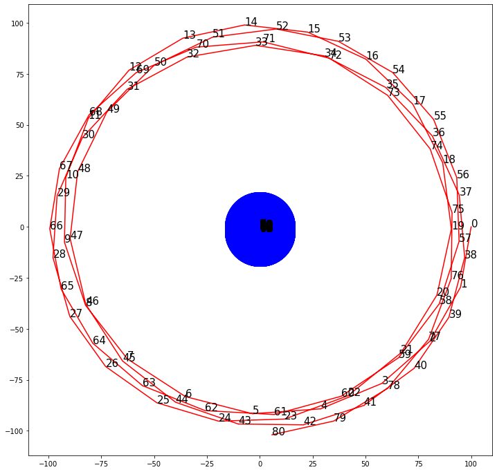

```python
#y = (x_0, y_0, x_1, y_1, dx_0, dy_0, dx_1, dy_1)

G   = 1
m_0 = 10.0
m_1 = 0.01

def F(t,y):
    x_0, y_0, x_1, y_1 = y[0:4]
    dist = np.sqrt((x_0-x_1)**2 + (y_0-y_1)**2 )

    F = np.zeros(8)
    F[0:4] = y[4:8]
    F[4]   = -G*m_1*(x_0-x_1)/dist**2
    F[5]   = -G*m_1*(y_0-y_1)/dist**2
    F[6]   = -G*m_0*(x_1-x_0)/dist**2
    F[7]   = -G*m_0*(y_1-y_0)/dist**2
    return F

#x = time
x_start = 0.0
x_stop  = 800.0
y_start = np.array([   0.0,  0.0, #0 x-y position
                     100.0,  0.0, #1 x-y position
                       0.0,  0.0, #0 x-y speed
                       0.0, -3.0  #1 x-y speed
                   ])
h       = 10.0
results_RK4 = integrate_RK4  (F, x_start, y_start, x_stop, h)


fig, ax = plt.subplots(figsize=(12, 12))
t_steps = results_RK4[0]
y_steps = results_RK4[1]

ax.plot(y_steps[:,0], y_steps[:,1], "-ob",  markersize=10*m_0)
ax.plot(y_steps[:,2], y_steps[:,3], "-or",  markersize=10*m_1)
for i in range(y_steps.shape[0]):
    ax.annotate("%d" % i, xy=(y_steps[i,0], y_steps[i,1]), xytext=(y_steps[i,0], y_steps[i,1]), fontsize=15 )
    ax.annotate("%d" % i, xy=(y_steps[i,2], y_steps[i,3]), xytext=(y_steps[i,2], y_steps[i,3]), fontsize=15 )

plt.show()
```